# Question

A thief is stealing xots and yivs. Each xot has a mass of 15 kilograms and a volume of 10 liters. Each yiv has a mass of 6 kilograms and a volume of 8 liters. The thief can carry a maximum mass of 90 kilograms and a maximum volume of 80 liters. The profit from each xot is $6.8 and the profit from each yiv is $4.41.

For your convenience, those numbers are organized in the table below.

| attribute | xot | yiv | capacity |
| --- | --- | --- | --- |
| mass (kg) | 15 | 6 | 90 |
| volume (L) | 10 | 8 | 80 |
| profit ($) | 6.80 | 4.41 | $\infty$ |

What is the maximum profit the thief can produce? *(In dollars.)*

# Solution

This is an example of [linear programming](https://en.wikipedia.org/wiki/Linear_programming).

Define $x$ as number of xots and $y$ as number of yivs. Write the constraints as inequalities.

- Mass constraint: $15x+6y \le 90$
- Volume constraint: $10x+8y \le 80$

We can assume that optimal profit will occur at a boundary, so we can just consider the equations.
$$15x+6y =
90$$
$$10x+8y = 80$$

If either equation has coefficients that all share a common factor, we can simplify by dividing both sides by the greatest common factor:

$$5x+2y = 30$$
$$5x+4y = 40$$

We need to find the $x$ intercepts and the $y$ intercepts.

To find the $x$-intercepts, set $y$ to 0.
$$5x_{\text{int}1}+(2)(0) = 30$$
$$5x_{\text{int}1} = 30$$
$$x_{\text{int}1} = \frac{30}{5} = 6$$

$$5x_{\text{int}2}+(4)(0) = 40$$
$$5x_{\text{int}2} = 40$$
$$x_{\text{int}2} = \frac{40}{5} = 8$$

To find the $y$-intercepts, set $x$ to 0.
$$(5)(0)+(2)(y_{\text{int1}}) = 30$$
$$2y_{\text{int}1} = 30$$
$$y_{\text{int}1} = \frac{30}{2} = 15$$

$$(5)(0)+(4)y_{\text{int2}} = 40$$
$$4y_{\text{int}2} = 40$$
$$y_{\text{int}2} = \frac{40}{4} = 10$$

To find the intersection, I would recommend elimination. Multiply the equations to have matching coefficients for $y$ terms.

$$10x + 4y = 60$$
$$5x + 4y = 40$$
Subtract equations.

$$5x + (0)y = 20$$

Simplify.

$$5x = 20$$

Divide by 5.

$$x = 4$$

Plug $x = 4$ into the first equation. Solve for $y$.

$$(5)(4)+2y = 30$$
$$20+2y = 30$$
$$2y = 10$$
$$y =
5$$

So, the intersection occurs at $(4,\,5)$.

You can plot the boundaries and shade the [feasible region](https://en.wikipedia.org/wiki/Feasible_region).

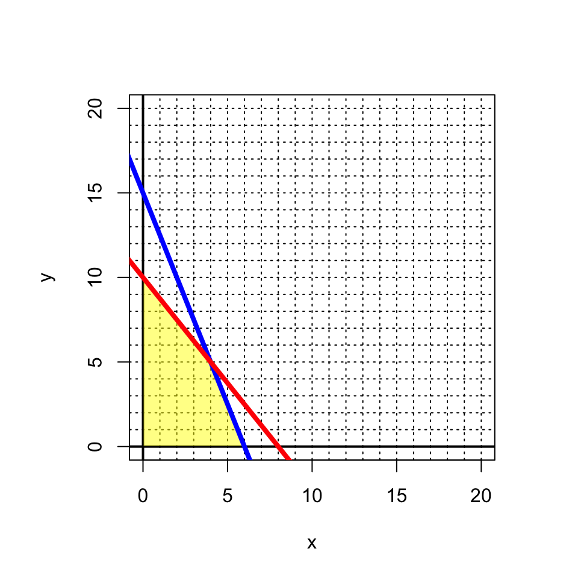

The maximum profit could occur at $(0,10)$ or $(4,5)$ or $(6,0)$.

Find those profits, using $P(x,y)=6.8x+4.41y$.

$$P(0,10)=(6.8)(0)+(4.41)(10) =
44.1$$
$$P(4,5)=(6.8)(4)+(4.41)(5) =
49.25$$
$$P(6,0)=(6.8)(6)+(4.41)(0) =
40.8$$

So, the maximum profit is $49.25.

It might help to visualize this in 3D, with xots, yivs, and profit on the 3 axes. Sorry, I was not able to make a 3D plot show up here.

# Meta-information

extype: num exsolution: 49.25 extol: 0.01 exname: opt_thief